# Vježba 1 - Uvod u tablične kalkulatore

Organiziranje, sortiranje, filtriranje i sažimanje podataka

Author

Elvis Starić

[figure not shown]

[figure not shown]

Vježba 1

Uvod u tablične kalkulatore

**Predavanja:** doc. dr. sc. Ivan Lorencin

**Vježbe:** Elvis Starić mag. inf.

U uvodnoj vježbi podatke smo ručno uredili, organizirali u tablicu i iz njih izveli nekoliko zaključaka. Takav je postupak izvediv kada imamo pet vrijednosti. U ovoj ćemo vježbi isti način razmišljanja prenijeti u tablični kalkulator, gdje podatke možemo mijenjati, sortirati, filtrirati, računati i prikazivati bez ponavljanja svih koraka ručno.

Vježbu možete izvesti u bilo kojem tabličnom kalkulatoru. Skripta opisuje postupke i očekivane rezultate, a ne položaj naredbi u pojedinom programu. Nazivi naredbi i izgled sučelja mogu se razlikovati, ali su osnovni pojmovi i način rada jednaki.

Tijekom vođenog dijela koristimo jedan izmišljeni skup studentskih rezultata. Svi nazivi i podaci služe isključivo za vježbu. Na kraju ćete iste postupke primijeniti na drugi skup podataka.

# 1 Što je tablični kalkulator?

Tablični kalkulator nije samo digitalni papir s nacrtanim redovima i stupcima. Njegova je glavna prednost u tome što povezuje **pohranu podataka** s njihovom **obradom**. Kada promijenimo ulaznu vrijednost, formule mogu automatski izračunati novi rezultat, a grafikon se može ažurirati prema promijenjenim podacima.

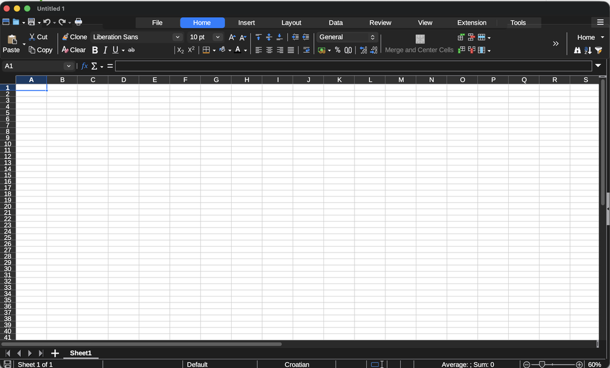

Tablični kalkulator

**TipDefinicija: tablični kalkulator**

**Tablični kalkulator** je program za organiziranje, pohranu, obradu i prikaz podataka u tabličnom obliku. Podaci su smješteni u ćelije organizirane u retke i stupce, a formule i ugrađene funkcije omogućuju izvođenje izračuna.

Primjeri tabličnih kalkulatora su LibreOffice Calc, Microsoft Excel, Google tablice i Apple Numbers. Različiti alati koriste različite formate radnih knjiga, primjerice `.ods` ili `.xlsx`. Jednostavni tablični podaci mogu se razmjenjivati i u formatu `.csv`, koji ćemo detaljnije obraditi kasnije.

## 1.1 Radna knjiga, radni list i ćelija

Kada u tabličnom kalkulatoru napravimo novu datoteku, dobivamo radnu knjigu koja može sadržavati jedan ili više radnih listova. Kartice radnih listova nalaze se pri dnu prozora.

**TipOsnovni pojmovi**

**Radna knjiga** je cijela datoteka tabličnog kalkulatora. Može sadržavati više radnih listova.

**Radni list** je jedna mreža ćelija unutar radne knjige. Listovi se mogu koristiti za odvajanje izvornih podataka, izračuna ili različitih razdoblja.

**Ćelija** je polje na sjecištu retka i stupca. Stupci su označeni slovima, a retci brojevima, pa svaka ćelija ima adresu poput `A1`, `C4` ili `F12`.

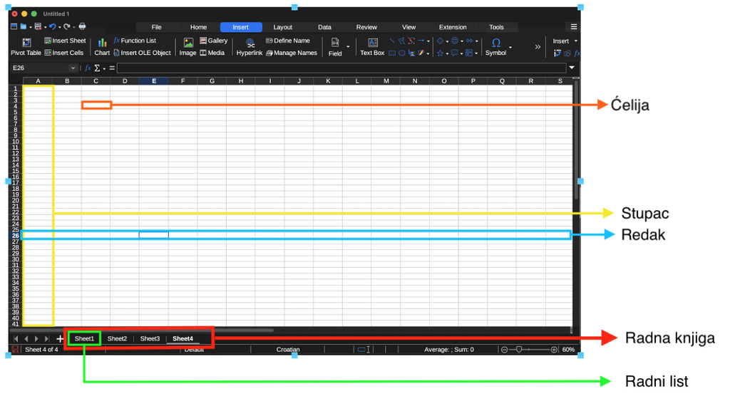

Komponenete tabličnih kalkulatora

Adresa `C4` znači da se ćelija nalazi u stupcu C i retku 4. Adresa nam omogućuje da u formuli kažemo iz kojih ćelija treba uzeti vrijednosti. Trenutačno odabranu ćeliju prepoznajemo po obrubu, a njezina je adresa prikazana lijevo od trake za formule.

# 2 Preuzimanje i priprema radne knjige

## 2.1 Preuzmite datoteku za vježbu

Preuzmite datoteku `vjezba-1.xlsx` s **Merlina** i otvorite je u tabličnom kalkulatoru po izboru. Radna knjiga sadrži dva pripremljena radna lista:

- `Rezultati`, koji ćemo koristiti u vođenom dijelu vježbe
- `Inventar`, koji ćete koristiti za samostalni zadatak.

Naziv radne knjige govori kojoj aktivnosti datoteka pripada, a naziv lista što se na njemu nalazi. Nazivi poput `Konačno`, `Novo` ili `List7` brzo postaju nejasni kada se u radnoj knjizi pojavi više listova.

## 2.2 Zapis brojeva i formula

Regionalna postavka utječe na prikaz datuma, decimalni separator i znak kojim razdvajamo argumente funkcije. U hrvatskoj postavci decimalni broj obično pišemo kao `67,5`, a više argumenata funkcije odvajamo točkom sa zarezom, primjerice:

```
=IF(H2>=60;"Prolaz";"Nije prolaz")
```

U ovoj skripti funkcije su zapisane engleskim nazivima, a argumenti su odvojeni točkom sa zarezom. Ako vaš program ne prihvati prikazanu formulu, provjerite očekuje li zarez između argumenata ili prevedeni naziv funkcije. Sama logika formule ostaje jednaka.

## 2.3 Pokazni primjer: radni list `Rezultati`

Odaberite radni list `Rezultati`. Na ovom ćemo pokaznom primjeru zajedno proći uređivanje, računanje, sortiranje, filtriranje i izradu grafikona. Podaci su već uneseni u raspon `A1:G13`, prije obrade provjerit ćemo njihovu strukturu i urediti prikaz.

## 2.4 Provjerite strukturu prije obrade

Nemojte odmah računati. Najprije provjerite je li tablica prenesena bez pogreške:

- prvi redak sadrži sedam različitih zaglavlja
- svaki sljedeći redak predstavlja jednog studenta
- ID oznake idu od `S01` do `S12`
- stupci `Dolasci`, `Zadatak 1` i `Zadatak 2` sadrže brojeve
- stupac `Predano` sadrži samo `Da` ili `Ne`
- nema potpuno praznog retka unutar tablice.

## 2.5 Uredite prikaz

**Zadatak:** uredite tablicu tako da se zaglavlje jasno razlikuje od podataka, svi sadržaji budu čitljivi, a zaglavlje ostane vidljivo pri pomicanju po listu.

**Postupak:**

1. Podebljajte prvi redak
2. Odaberite boju pozadine koja zaglavlje jasno razlikuje od podataka
3. Prilagodite širinu stupaca tako da su zaglavlja i vrijednosti vidljivi
4. Zamrznite prvi redak odgovarajućom naredbom svojeg programa.

Zamrznuti redak ostaje vidljiv tijekom pomicanja po većoj tablici. To ne mijenja podatke, nego samo način na koji ih vidimo.

**Prikaži očekivani rezultat**

Tablica treba imati jasno istaknuto zaglavlje i vidljive cjelovite nazive stupaca. Pri pomicanju prema dnu lista prvi redak treba ostati vidljiv.

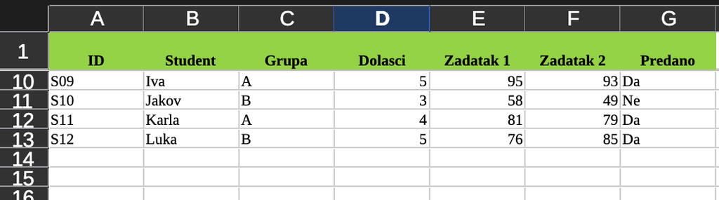

Očekivani izgled uređene tablice

# 3 Formule i funkcije

## 3.1 Formula počinje znakom jednakosti

**Zadatak:** za svakog studenta izračunajte prosjek bodova iz stupaca `Zadatak 1` i `Zadatak 2`.

**Postupak:**

1. U praznu ćeliju `H1` upišite zaglavlje `Prosjek`
2. Odaberite ćeliju `H2`
3. Upišite sljedeću formulu i pritisnite Enter:

```
=AVERAGE(E2:F2)
```

**TipDefinicije: formula, funkcija i raspon**

**Formula** je izraz kojim tabličnom kalkulatoru zadajemo izračun. Počinje znakom `=`.

**Funkcija** je unaprijed definirana operacija. Funkcija `AVERAGE` računa aritmetičku sredinu brojčanih vrijednosti.

**Raspon** je skup ćelija. Zapis `E2:F2` označava sve ćelije od `E2` do `F2`, uključujući obje krajnje ćelije.

Formula `=AVERAGE(E2:F2)` uzima bodove iz ćelija `E2` i `F2`, zbraja ih i dijeli s brojem brojčanih vrijednosti. Za Anu računa `(78 + 84) / 2 = 81`.

4. Ponovno odaberite `H2` i usporedite vrijednost prikazanu u ćeliji s formulom prikazanom u traci za formule.

U ćeliji vidite rezultat, a u traci za formule iznad lista formulu koja ga je proizvela. Rezultat i formula nisu isto: formula se čuva u ćeliji, a prikazana vrijednost izračunava se iz trenutačnih ulaznih podataka.

**Prikaži očekivani rezultat prve formule**

[figure not shown]

Očekivani rezultat formule u ćeliji H2

**Kopiranje formule na sve studente:**

1. Odaberite ćeliju `H2`
2. Pronađite mali kvadratić u njezinu donjem desnom kutu, odnosno **ručicu za ispunu**
3. Povucite ručicu do retka 13 ili je dvaput kliknite kako biste formulu kopirali na sve studente
4. Otvorite nekoliko ćelija u stupcu H i provjerite formule u traci za formule.

U retku 3 formula treba biti `=AVERAGE(E3:F3)`, a u retku 13 `=AVERAGE(E13:F13)`. Tablični kalkulator automatski je prilagodio reference retku u koji je formula kopirana.

**Prikaži očekivane prosjeke**

| Student | Prosjek |
| --- | --- |
| Ana | 81 |
| Bruno | 67,5 |
| Carla | 90 |
| David | 58 |
| Ema | 74,5 |
| Filip | 89,5 |
| Gita | 49,5 |
| Hrvoje | 66,5 |
| Iva | 94 |
| Jakov | 53,5 |
| Karla | 80 |
| Luka | 80,5 |

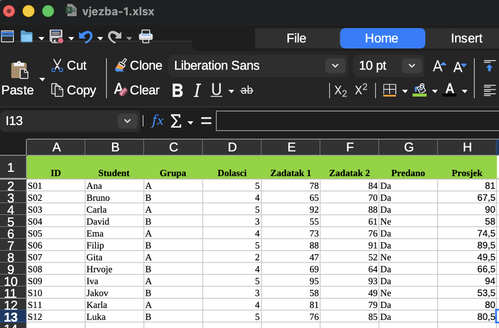

Očekivani prosjeci svih studenata

Promijenite Anin rezultat u ćeliji `E2` s `78` na `80`. Prosjek u `H2` trebao bi se automatski promijeniti s `81` na `82`. Vratite vrijednost `E2` na `78` prije nastavka.

Ova mala izmjena pokazuje glavnu prednost formule: ne spremamo samo gotov odgovor, nego i pravilo prema kojem se odgovor izračunava.

## 3.2 Prosjek cijelog raspona

Do sada smo računali prosjek dvaju zadataka za svakog studenta, odnosno prosjek vrijednosti u istom retku. Sada želimo izračunati **prosjek svih studenata za Zadatak 1**, pa u izračun uključujemo vrijednosti iz istog stupca.

**Zadatak:** izračunajte prosjek rezultata svih studenata za `Zadatak 1`.

**Postupak:**

1. U ćeliju `J1` upišite `Sažetak`
2. U ćeliju `J2` upišite `Prosjek zadatka 1`
3. U ćeliju `K2` unesite:

```
=AVERAGE(E2:E13)
```

Znak `:` označava cijeli neprekinuti raspon od prve do posljednje navedene ćelije. Zato `E2:E13` uključuje ćelije `E2`, `E3`, `E4` i sve ostale do `E13`.

Kada bismo funkciji prosljeđivali pojedinačne ćelije, odvajali bismo ih točkom sa zarezom. Primjerice, prosjek samo prve tri vrijednosti mogli bismo zapisati kao:

```
=AVERAGE(E2;E3;E4)
```

Budući da su sve ćelije od `E2` do `E13` susjedne, zapis raspona `E2:E13` kraći je, pregledniji i smanjuje mogućnost da neku ćeliju izostavimo.

**Prikaži očekivani rezultat**

Prosjek svih studenata za Zadatak 1 iznosi `73,0833...`.

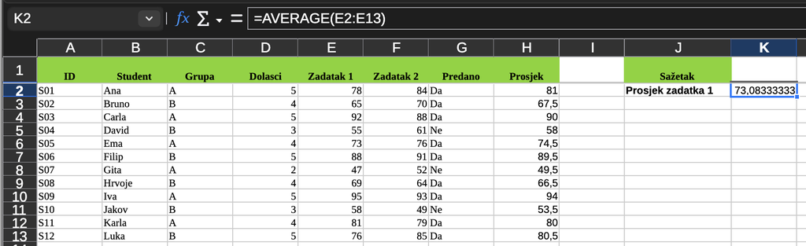

Očekivani prosjek svih studenata za Zadatak 1

## 3.3 Ostali sažeci

**Zadatak:** izračunajte prosjek drugog zadatka te prebrojite brojčane, neprazne i uvjetno odabrane vrijednosti.

**Postupak:**

1. U ćelije `J3:J6` unesite sljedeće opise:

   | Ćelija | Sadržaj |
   | --- | --- |
   | J3 | Prosjek zadatka 2 |
   | J4 | Broj rezultata zadatka 1 |
   | J5 | Broj studenata |
   | J6 | Broj predanih radova |

2. U ćelije `K3:K6` redom unesite formule:

```
=AVERAGE(F2:F13)
=COUNT(E2:E13)
=COUNTA(B2:B13)
=COUNTIF(G2:G13;"Da")
```

3. Označite ćelije `K2:K3` i postavite prikaz na dvije decimale.

**TipFunkcije za računanje i brojanje**

`AVERAGE` računa aritmetičku sredinu brojčanih vrijednosti u rasponu.

`COUNT` broji ćelije koje sadrže brojeve. Tekstualne i prazne ćelije ne ulaze u rezultat.

`COUNTA` broji sve ćelije koje nisu prazne, neovisno o tome sadrže li broj ili tekst.

`COUNTIF` broji ćelije koje zadovoljavaju zadani uvjet. U formuli `=COUNTIF(G2:G13;"Da")` uvjet je tekst `Da`.

**Prikaži očekivane rezultate sažetka**

| Sažetak | Rezultat |
| --- | --- |
| Prosjek zadatka 1 | 73,0833… |
| Prosjek zadatka 2 | 74,3333… |
| Broj rezultata zadatka 1 | 12 |
| Broj studenata | 12 |
| Broj predanih radova | 9 |

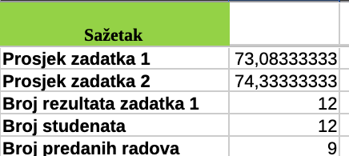

Očekivani izgled sažetka

Rezultat prosjeka može sadržavati puno decimala. Postavljanjem prikaza na dvije decimale mijenjate **prikaz**, a ne vrijednost koju tablica čuva i koristi u daljnjim izračunima.

**WarningPrazna ćelija nije isto što i nula**

Funkcija `AVERAGE` zanemaruje praznu ćeliju, ali broj `0` uključuje u prosjek. Nulu unosimo samo kada stvarno znači izmjerenu ili ostvarenu vrijednost nula. Ako rezultat nije poznat ili nije zabilježen, ne zamjenjujemo ga nulom bez opravdanog pravila.

# 4 Sortiranje podataka

Sortiranje mijenja redoslijed redaka prema vrijednostima odabranog stupca. Ne uklanja retke i ne mijenja same vrijednosti.

**WarningJedan redak mora ostati jedna cjelina**

Vrijednosti u istom retku pripadaju istom studentu. Ako sortiramo samo jedan stupac, imena i rezultati više neće odgovarati jedni drugima. Zato pri sortiranju moramo obuhvatiti cijelu tablicu.

**Zadatak:** poredajte studente od najvećeg prema najmanjem prosjeku, pri čemu svi podaci o pojedinom studentu moraju ostati u istom retku.

**Postupak:**

1. Označite raspon cijele tablice `A1:H13`
2. Pokrenite naredbu za sortiranje podataka
3. Naznačite da prvi redak sadrži zaglavlja
4. Kao ključ sortiranja odaberite stupac `Prosjek`
5. Odaberite silazni redoslijed, od najveće prema najmanjoj vrijednosti, i potvrdite sortiranje.

**Prikaži provjeru rezultata**

Prva tri studenta trebaju biti:

1. Iva - 94
2. Carla - 90
3. Filip - 89,5

Posljednja tri trebaju biti David, Jakov i Gita, a Gita s prosjekom 49,5 treba biti posljednja.

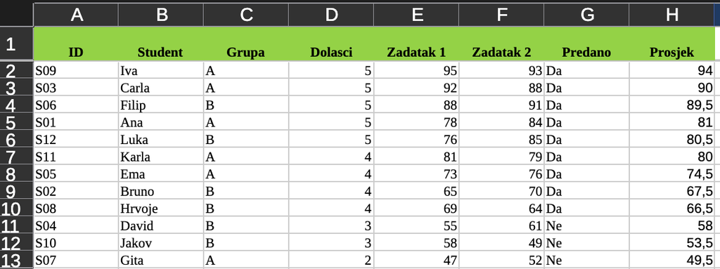

Očekivani rezultat sortiranja

Provjerite jedan redak prema izvornoj tablici. Iva i dalje mora imati rezultate 95 i 93, a oznaka predaje mora ostati `Da`. Ako su se pomaknule samo vrijednosti u stupcu Prosjek, sortirali ste samo jedan stupac i narušili veze među podacima. Poništite radnju s `Ctrl + Z` ili `Cmd + Z` i ponovite sortiranje cijelog raspona.

Nakon provjere ponovno sortirajte cijelu tablicu uzlazno prema stupcu `ID`. Time vraćamo početni redoslijed od `S01` do `S12`, koji ćemo koristiti u sljedećim koracima i na grafikonu.

**TipDefinicija: sortiranje**

**Sortiranje** uređuje retke prema vrijednostima jednog ili više stupaca. Uzlazni redoslijed ide od manjeg prema većem odnosno od A prema Z, a silazni od većeg prema manjem odnosno od Z prema A.

# 5 Filtriranje podataka

Sortiranjem vidimo sve retke u drugom redoslijedu. Filtriranjem privremeno prikazujemo samo retke koji zadovoljavaju odabrane uvjete.

**Zadatak:** privremeno prikažite samo retke koji zadovoljavaju zadane uvjete, bez brisanja ostalih podataka.

## 5.1 Prikažite samo jednu grupu

**Postupak:**

1. Označite cijelu tablicu `A1:H13`
2. Uključite filtriranje (u zaglavljima će se pojaviti kontrole filtra)
3. Otvorite filtar u stupcu `Grupa`
4. Uklonite odabir svih vrijednosti
5. Označite samo vrijednost `A` i primijenite filtar.

Primijetite da brojevi redaka više nisu uzastopni. Redci druge grupe nisu izbrisani, samo privremeno skriveni.

**Prikaži očekivani rezultat**

Trebali biste vidjeti šest studenata: Anu, Carlu, Emu, Gitu, Ivu i Karlu.

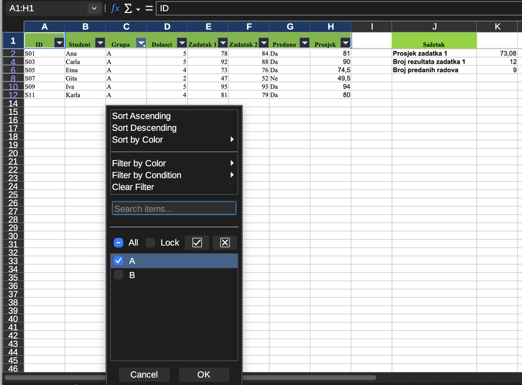

Očekivani rezultat filtriranja grupe A

## 5.2 Kombinirajte više uvjeta filtra

**Postupak:**

1. Zadržite postojeći uvjet `Grupa = A`
2. Otvorite mogućnosti filtra za stupac `Zadatak 1`
3. Dodajte brojčani uvjet `veće od ili jednako 70`
4. Primijenite filtar.

Ovisno o programu, brojčani uvjet može se postaviti izravno u kontroli stupca ili u posebnom prozoru za filtriranje.

**Prikaži očekivani rezultat**

Trebali biste vidjeti Anu, Carlu, Emu, Ivu i Karlu. Gita pripada grupi A, ali ima 47 bodova iz prvog zadatka, pa ne zadovoljava drugi uvjet.

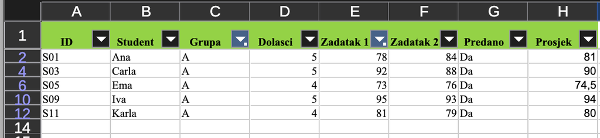

Očekivani rezultat kombiniranog filtra

Ova dva filtra povezana su operatorom `AND`: redak mora zadovoljiti oba uvjeta kako bi ostao prikazan.

**Povratak na cijelu tablicu:**

1. Uklonite uvjete postavljene na stupcima `Grupa` i `Zadatak 1`
2. Provjerite prikazuje li tablica ponovno svih 12 studenata.

**TipDefinicija: filtriranje**

**Filtriranje** privremeno prikazuje samo retke koji zadovoljavaju zadane uvjete. Ostali retci ostaju u tablici, ali su skriveni dok je filtar aktivan.

**NoteFiltriranje ne mijenja izvorne podatke**

Programi mogu nuditi više vrsta filtara i njihove se kontrole mogu razlikovati. U svakom slučaju provjeravamo uvjet i dobiveni skup redaka. Filtriranje ne prepisuje vrijednosti i ne briše retke uklanjanjem filtra ponovno prikazujemo cijelu tablicu.

# 6 Grafički prikaz rezultata

Grafikon izrađujemo zato što imamo pitanje na koje vizualni prikaz može jasno odgovoriti. Želimo usporediti rezultate dvaju zadataka za svakog studenta.

**Zadatak:** izradite grafikon na kojem se za svakog studenta mogu usporediti bodovi iz prvog i drugog zadatka.

**Postupak:**

1. Pokrenite izradu novog grafikona
2. Kao oznake kategorija postavite imena studenata iz raspona `B2:B13`
3. Kao prvi niz podataka postavite vrijednosti `Zadatak 1` iz raspona `E2:E13`
4. Kao drugi niz podataka postavite vrijednosti `Zadatak 2` iz raspona `F2:F13`
5. Odaberite stupčasti grafikon i postavite naslov `Rezultati zadataka po studentu`
6. Provjerite jesu li nazivi nizova preuzeti iz zaglavlja `E1` i `F1`.

Neki programi omogućuju da raspone odaberete prije umetanja grafikona, a u drugima ih je jednostavnije zadati tijekom uređivanja grafikona. Važno je da imena studenata postanu oznake kategorija, a rezultati dvaju zadataka dva odvojena niza podataka.

**Prikaži očekivani rezultat i provjeru**

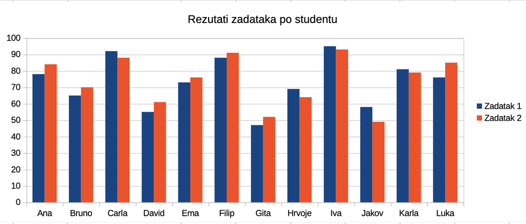

Primjer očekivanog stupčastog grafikona.

Grafikon treba zadovoljiti sljedeće uvjete:

- naslov govori što prikazujemo
- uz svakog studenta nalaze se dva stupca
- legenda razlikuje `Zadatak 1` i `Zadatak 2`
- brojčana os ima smislen raspon i počinje od nule
- grafikon ne sadrži stupce `Dolasci` ili `Prosjek`, jer ih nismo uključili u pitanje.

**Provjera automatskog ažuriranja:**

1. Promijenite jednu vrijednost u tablici
2. Provjerite je li se pripadajući stupac na grafikonu ažurirao
3. Vratite izvornu vrijednost.

**TipZašto stupčasti grafikon?**

Studenti su kategorije koje uspoređujemo, a bodovi su brojčane vrijednosti. Stupčasti grafikon omogućuje usporedbu visina stupaca među studentima i između dvaju zadataka.

Linijski grafikon ovdje bi mogao stvarati dojam neprekinutog procesa između susjednih studenata. Takva veza ne postoji, pa je stupčasti prikaz primjereniji.

# 7 IF, AND i OR

Formule ne moraju služiti samo računanju brojeva. Mogu provjeravati zadovoljavaju li podaci određeno pravilo i na temelju rezultata automatski ispisati oznaku, upozorenje ili odluku. Primjerice, možemo provjeriti je li student ostvario dovoljan broj bodova ili treba li neki redak dodatno pregledati.

Takve provjere temelje se na **logičkim izrazima**. Logički izraz može imati samo jedan od dva rezultata:

- `TRUE` – uvjet je ispunjen
- `FALSE` – uvjet nije ispunjen.

Primjer `H2>=60` provjerava je li vrijednost u ćeliji `H2` veća ili jednaka 60. Ako se u `H2` nalazi 81, rezultat izraza je `TRUE`. Izraz `C2="A"` provjerava pripada li student u tom retku grupi A.

**TipOperatori usporedbe**

| Operator | Značenje | Primjer |
| --- | --- | --- |
| `=` | jednako | `C2="A"` |
| `<>` | nije jednako | `C2<>"A"` |
| `>` | veće od | `H2>60` |
| `>=` | veće od ili jednako | `H2>=60` |
| `<` | manje od | `D2<3` |
| `<=` | manje od ili jednako | `D2<=3` |

Kod usporedbe teksta vrijednost pišemo unutar navodnika. Brojčane vrijednosti pišemo bez navodnika.

## 7.1 Funkcija IF

Funkcija `IF` provjerava jedan logički uvjet i vraća različit rezultat ovisno o tome je li uvjet istinit ili neistinit. Opći oblik je:

```
=IF(uvjet; rezultat_ako_je_TRUE; rezultat_ako_je_FALSE)
```

Funkcija ima tri dijela:

1. Uvjet koji provjeravamo
2. Rezultat koji želimo dobiti kada je uvjet ispunjen
3. Rezultat koji želimo dobiti kada uvjet nije ispunjen.

**Zadatak:** označite je li student ostvario prosjek od najmanje 60 bodova.

**Postupak:**

1. U ćeliju `I1` upišite `Status`
2. U ćeliju `I2` unesite:

```
=IF(H2>=60;"Prolaz";"Nije prolaz")
```

3. Kopirajte formulu do retka 13.

U ovoj formuli:

- `H2>=60` predstavlja uvjet
- `"Prolaz"` je rezultat kada je uvjet `TRUE`
- `"Nije prolaz"` je rezultat kada je uvjet `FALSE`.

Ana u ćeliji `H2` ima prosjek 81. Budući da je 81 veće ili jednako 60, uvjet je istinit i funkcija ispisuje `Prolaz`. Kada formula dođe do Gitina retka, prosjek 49,5 ne zadovoljava uvjet pa funkcija ispisuje `Nije prolaz`.

**Prikaži provjeru**

Status `Nije prolaz` trebaju imati David, Gita i Jakov. Ostali trebaju imati `Prolaz`.

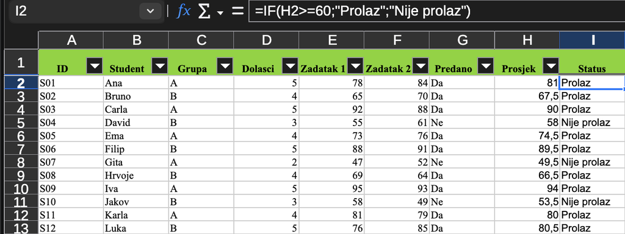

Očekivani rezultat funkcije IF

## 7.2 Funkcija AND

Ponekad jedan uvjet nije dovoljan. Funkcija `AND` povezuje više uvjeta i vraća `TRUE` samo kada su **svi** navedeni uvjeti ispunjeni, a ako je **jedan ili više** uvjeta neispunjen rezultata je `FALSE`. Opći oblik je:

```
=AND(uvjet1; uvjet2; uvjet3)
```

**Zadatak:** provjerite ima li student najmanje tri dolaska **i** najmanje 50 bodova iz svakog zadatka.

**Postupak:**

1. Odaberite ćeliju `I2` i zamijenite prethodnu formulu
2. Unesite:

```
=IF(AND(D2>=3;E2>=50;F2>=50);"Uvjet zadovoljen";"Uvjet nije zadovoljen")
```

3. Kopirajte formulu do retka 13.

Funkcija `AND` u ovom primjeru provjerava tri uvjeta:

1. `D2>=3` – student ima najmanje tri dolaska
2. `E2>=50` – iz prvog zadatka ima najmanje 50 bodova
3. `F2>=50` – iz drugog zadatka ima najmanje 50 bodova.

Rezultat funkcije `AND` postaje uvjet funkcije `IF`. Ako su sva tri dijela istinita, `IF` ispisuje `Uvjet zadovoljen`. Ako barem jedan nije istinit, ispisuje `Uvjet nije zadovoljen`.

Primjerice, Ana zadovoljava sva tri uvjeta. Jakov ima dovoljno dolazaka i bodova iz prvog zadatka, ali iz drugog zadatka ima 49 bodova. Jedan neistinit uvjet dovoljan je da cijeli `AND` vrati `FALSE`.

**Prikaži provjeru**

Uvjet ne zadovoljavaju Gita, koja ima samo dva dolaska i 47 bodova iz prvog zadatka, te Jakov, koji ima 49 bodova iz drugog zadatka. Ostali ga zadovoljavaju.

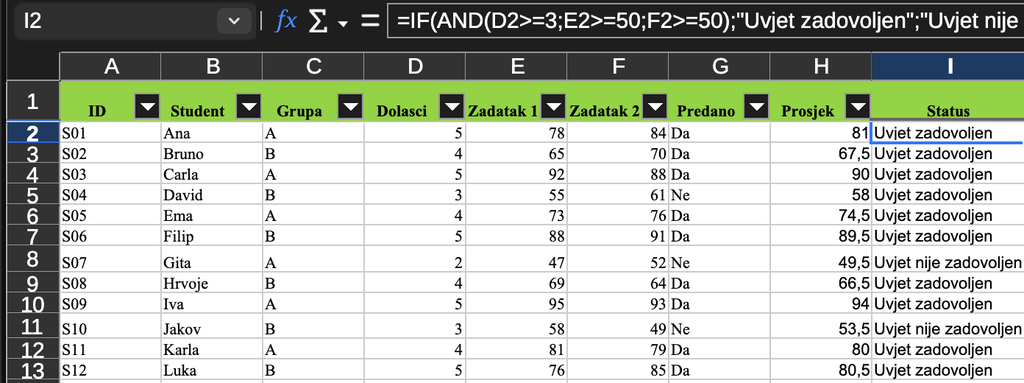

Očekivani rezultat funkcija IF i AND

## 7.3 Funkcija OR

Funkcija `OR` također povezuje više uvjeta, ali vraća `TRUE` kada je ispunjen **barem jedan** od njih, a `FALSE` samo kada **nijedan** navedeni uvjet nije ispunjen. Opći oblik je:

```
=OR(uvjet1; uvjet2)
```

**Zadatak:** označite retke koje treba dodatno provjeriti jer student ima manje od tri dolaska **ili** rad nije predan.

**Postupak:**

1. Odaberite ćeliju `I2` i zamijenite prethodnu formulu
2. Unesite:

```
=IF(OR(D2<3;G2="Ne");"Provjeriti";"U redu")
```

3. Kopirajte formulu do retka 13.

Funkcija `OR` ovdje provjerava:

1. `D2<3` – student ima manje od tri dolaska
2. `G2="Ne"` – rad nije predan.

Ako je barem jedan od tih uvjeta istinit, funkcija `IF` ispisuje `Provjeriti`. Samo kada student ima najmanje tri dolaska i predan rad, oba uvjeta unutar `OR` bit će neistinita pa će rezultat biti `U redu`.

David ima tri dolaska, pa prvi uvjet nije ispunjen, ali rad nije predao. Drugi uvjet zato je dovoljan da `OR` vrati `TRUE`. Gita ima manje od tri dolaska i nije predala rad, pa su kod nje ispunjena oba uvjeta.

**Prikaži provjeru**

Oznaku `Provjeriti` trebaju imati David, Gita i Jakov. David i Jakov označeni su zbog vrijednosti `Ne` u stupcu Predano, a Gita zadovoljava oba razloga za provjeru.

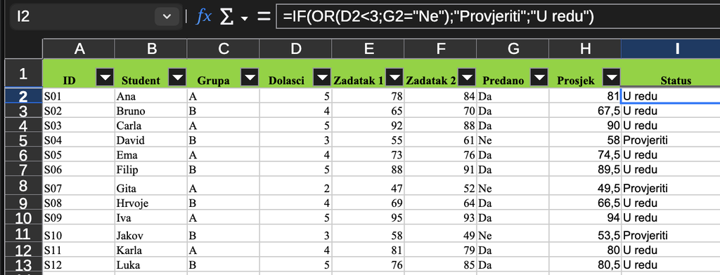

Očekivani rezultat funkcija IF i OR

**NoteAko formula javlja pogrešku**

Provjerite počinje li znakom `=`, jesu li svi tekstovi u ravnim navodnicima te jesu li zatvorene sve zagrade. Ako dokument nije postavljen na Hrvatsku, možda umjesto točke sa zarezom očekuje zarez između argumenata.

# 8 Samostalni zadatak: inventar

Otvorite radni list `Inventar` u preuzetoj datoteci. Podaci o proizvodima već su uneseni, na njima samostalno primijenite postupke iz vođenog dijela vježbe.

Svaki rezultat ostavite vidljiv u radnom listu. Novi zadatak ne smije izbrisati ili zamijeniti rezultat prethodnog zadatka.

## 8.1 Zadatak 1 - Priprema tablice

1. Uredite zaglavlje tako da se jasno razlikuje od podataka
2. Prilagodite širine stupaca i zamrznite prvi redak
3. Stupac `Jedinična cijena` oblikujte kao valutu u eurima
4. Provjerite je li svaki proizvod u jednom retku te jesu li količina i cijena prepoznate kao brojevi.

## 8.2 Zadatak 2 - Izračun vrijednosti zalihe

1. Dodajte novi stupac `Vrijednost zalihe`
2. Za svaki proizvod izračunajte ukupnu vrijednost svih primjeraka na zalihi
3. Rezultate prikažite kao iznose u eurima.

## 8.3 Zadatak 3 - Prosjek i brojanje

U odvojenom području radnog lista, uz jasne oznake, prikažite:

1. Prosječnu jediničnu cijenu svih proizvoda
2. Broj brojčanih vrijednosti u stupcu Količina
3. Broj nepraznih naziva proizvoda.

## 8.4 Zadatak 4 - Sortiranje i filtriranje

1. Sortirajte cijelu tablicu uzlazno prema količini
2. U odvojenom području radnog lista zabilježite prva tri proizvoda nakon sortiranja
3. Prikažite samo proizvode koji pripadaju kategoriji `Pisaći pribor` i imaju količinu manju od 15
4. U odvojenom području radnog lista zabilježite proizvode koji su ostali prikazani
5. Ponovno prikažite sve proizvode.

## 8.5 Zadatak 5 - Grafikon

1. Izradite grafikon koji uspoređuje količine proizvoda na zalihi
2. Naslov grafikona promijenite u `Količina proizvoda na zalihi`.

## 8.6 Zadatak 6 - Automatska oznaka

1. Dodajte stupac `Status zalihe`
2. Za proizvode čija je količina manja od 10 prikažite oznaku `Naručiti`, a za ostale `Dovoljno`
3. Dodajte zaseban stupac `Prioritet nabave`
4. U njemu proizvodima iz kategorije `Elektronika` s količinom manjom od 10 prikažite oznaku `Prioritet`, a svim ostalima `Redovno`.

# 9 Rješenja samostalnog zadatka

## 9.1 Rješenje zadatka 2

U ćeliju `E2` upisujemo:

```
=C2*D2
```

Nakon kopiranja formule očekivane vrijednosti su:

| Proizvod | Vrijednost zalihe |
| --- | --- |
| Bilježnica A5 | 45,00 € |
| Kemijska plava | 8,40 € |
| Olovka HB | 20,00 € |
| Mapa A4 | 17,00 € |
| USB 32 GB | 76,50 € |
| Kalkulator | 56,00 € |
| Flomasteri | 57,60 € |
| Papir A4 | 138,00 € |

## 9.2 Rješenje zadatka 3

Ako su podaci u retcima 2 do 9, formule su:

```
=AVERAGE(D2:D9)
=COUNT(C2:C9)
=COUNTA(A2:A9)
```

**Prikaži rezultate**

- prosječna jedinična cijena: `5,2625 €`, odnosno `5,26 €` prikazano na dvije decimale
- broj brojčanih vrijednosti u stupcu Količina: `8`
- broj nepraznih naziva proizvoda: `8`.

## 9.3 Rješenje zadatka 4

Nakon uzlaznog sortiranja prema količini prva tri proizvoda trebaju biti:

1. Kalkulator - 4
2. Mapa A4 - 5
3. Kemijska plava - 7.

Nakon filtriranja kategorije `Pisaći pribor` i količine manje od 15 trebaju ostati:

| Proizvod | Količina |
| --- | --- |
| Kemijska plava | 7 |
| Flomasteri | 12 |

## 9.4 Rješenje zadatka 5

Grafikon treba imati osam stupaca, po jedan za svaki proizvod. Najviši stupac treba pripadati proizvodu `Olovka HB` s količinom 25, a najniži proizvodu `Kalkulator` s količinom 4. Brojčana os treba početi od nule.

## 9.5 Rješenje zadatka 6

U ćeliju `F1` upisujemo `Status zalihe`, a u `F2`:

```
=IF(C2<10;"Naručiti";"Dovoljno")
```

Formulu kopiramo do posljednjeg proizvoda. Oznaku `Naručiti` trebaju dobiti Kemijska plava, Mapa A4, USB 32 GB i Kalkulator.

U ćeliju `G1` upisujemo `Prioritet nabave`, a u `G2`:

```
=IF(AND(B2="Elektronika";C2<10);"Prioritet";"Redovno")
```

Formulu kopiramo do posljednjeg proizvoda. Oznaku `Prioritet` trebaju dobiti USB 32 GB i Kalkulator. Oba stupca ostaju u radnom listu kako bi se oba rezultata mogla provjeriti.